# filter-mtex.tcl documentation

Detlef Groth, Caputh-Schwielowsee, Germany

Nov 30, 2024

filter-abc - filter-cmd - filter-dot - filter-emf - filter-eqn - filter-julia - filter-kroki - filter-mmd - filter-mtex - filter-pic/dpic - filter-pik  
filter-pipe - filter-puml - filter-rplot - filter-sqlite - filter-tcrd - filter-tcl - filter-tdot - filter-tsvg

Documentation: Pantcl filter documentation - Pantcl tutorial - Pantcl Readme - Pantcl Gui

## Name

*filter-mtex.tcl* - Filter which can be used to display LaTeX equations and LaTeX generated figures within a Pandoc processed document using the Tcl filter driver `pantcl.bin`.

## Usage

The conversion of the Markdown documents via Pandoc should be done as follows:

```
pandoc input.md --filter pantcl.bin -s -o output.html
```

Alternatively since version 0.4.0 the filter comes as well as a stand alone application and can be used like this:

```
pantcl.bin input.md output.html -s --css mini.css
```

This can be used as well do extract Markdown code behind `#’’ comments like in the source of this file - filter-mtex.tcl itself. The document can be processed like this:

```
pantcl.bin filter-mtex.tcl filter-mtex.html -s --css mini.css
```

All arguments that pandoc accepts can be added after the output file.

The following options can be given via code chunks or in the YAML header.

> - eval - should the code in the code block be evaluated, default: false
> - ext - file file extension, can be svg (needs texlive-dvisvgm - https://dvisvgm.de/ or pdf2svg - https://github.com/dawbarton/pdf2svg), png, pdf, default: png
> - fig - should a figure be created, default: true
> - header - file with LaTeX code to be included in the document preamble, useful for embed more extensive package configurations and macros, default: null
> - imagepath - output imagepath, default: images
> - include - should the created image be automatically included, default: true
> - latex - which latex engine should be used, latex (using dbipng, divisvgm or dvipdfm), xelatex (convert, pdf2svg) and and dvips (latex, dvips, ps2pdf, pdf2svg or convert) default: latex
> - packages - space separated list of packages which should be included in the LaTeX preamble if null, just amsmath and xcolor will be loaded, default: null
> - resize - if latex engine pdflatex or latex the percent to resize the final png image, default: 100%
> - results - should the output of the command line application been shown, should be show or hide, default: hide

The option *eval* should be set to true or 1 to enable code evaluation.

To change the code chunk defaults for a complete document, the YAML header should be used. Here an example to change the default image output path to *nfigures* and the filename extension to *pdf* and to use the *chemformula* LaTeX package:

```
 ----
 title: "filter-mtex.tcl documentation"
 author: "Detlef Groth, Caputh-Schwielowsee, Germany"
 date: 2022-01-22
 mtex:
     imagepath: nfigures
     packages: chemformula
     latex:    pdflatex
     ext: pdf
     eval: 1
 ----
```

## Installation / Requirements

The filter needs an existing LaTeX installation and the LaTeX packages *standalone* and *preview*.

In the background quite a set of different tools is used such as convert (conversion to png if first output is pdf), `pdf2svg` or if LaTeX engine is latex `dvi2svgm` for conversion into svg. Here a table with the required tools:

> | latex | png | pdf | svg |
> | --- | --- | --- | --- |
> | latex | dvipng | dvipdfm | dvisvgm |
> | dvips | convert | ps2pdf | pdf2svg |
> | xelatex/pdflatex | convert | - | pdf2svg |

## Examples

LaTeX Math

````
    ```{.mtex eval=true}
    $ E=mc^2 $
    ```
````

```
$ E=mc^2 $
```

[output not shown]

Now an example for the align environment:

```
\begin{align*}
2x - 5y &=  8 \\
3x + 9y &=  -12
\end{align*}
```

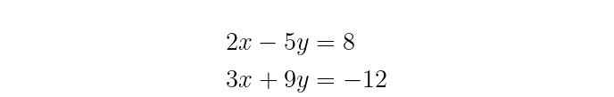

An here for the multiline environment:

```
\begin{multline*}
p(x) = 3x^6 + 14x^5y + 590x^4y^2 + 19x^3y^3\\
- 12x^2y^4 - 12xy^5 + 2y^6 - a^3b^3
\end{multline*}
```

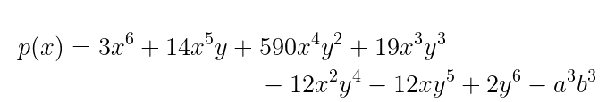

Now using colors with the xcolor package:

```
\color{red}{
\begin{multline*}
p(x) = 3x^6 + 14x^5y + 590x^4y^2 + 19x^3y^3\\
- 12x^2y^4 - 12xy^5 + 2y^6 - a^3b^3
\end{multline*}
}
```

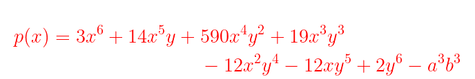

Large brackets:

```
$$
\left[ \frac{ N } { \left( \frac{L}{p} \right)  - (m+n) }  \right]
$$
```

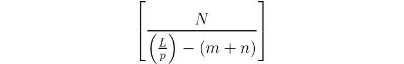

And now a matrix:

```
$$
\begin{bmatrix}
1 & 2 & 3\\
a & b & c\\
d & e & f
\end{bmatrix}
$$
```

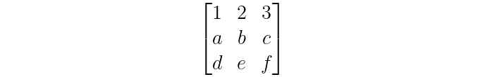

Let’s look if errors are catched:

```
$$
\begin{xmatrix}
1 & 2 & 3\\
a & b & c\\
d & e & f
\end{xmatrix}
$$
```

[output not shown]

### Chemical formulas

It is as well possible to use other LaTeX packages, here an example to use the *chemformula* package for displaying chemical equations.

```
\begin{align*}
\ch{
  RNO2      &<=>[ + e- ] RNO2^{-.} \\
  RNO2^{-.} &<=>[ + e- ] RNO2^2-
}
\end{align*}
```

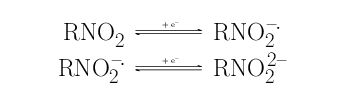

### Games and Hobby

Now demonstration of some game packages.

Here the display of a chessboard (`{.mtex packages="skak"}`):

```
\largeboard
\newgame
\fenboard{r5k1/1b1p1ppp/p7/1p1Q4/2p1r3/PP4Pq/BBP2b1P/R4R1K w - - 0 20}
\showboard
```

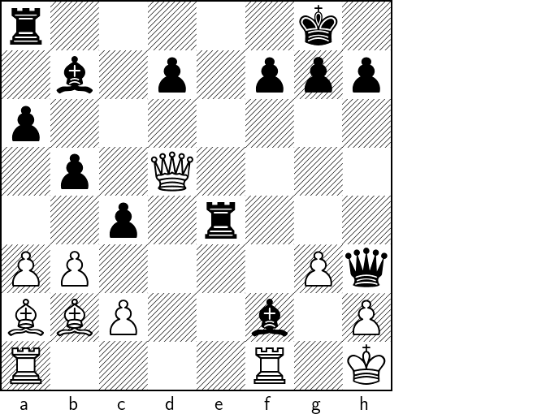

Here the display of a GO game (`{.mtex packages="psgo" latex="dvips"}`):

```
\begin{psgoboard*}[9]
\move*{c}{3}
\move*{g}{7}
\move*{g}{4}
\move*{c}{7}
\move*{e}{7}
\move{f}{6}
\move{e}{6}
\move{c}{5}
\end{psgoboard*}
```

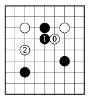

The *psgo* package us using the *pstricks* package and so needs a special conversion via *dvips* so that’s why the LaTeX engine must be set to *dvips*.

Next we display a sudoku (`{.mtex packages="sudoku"}`):

```
\begin{sudoku}
|2|5| | |3| |9| |1|.
| |1| | | |4| | | |.
|4| |7| | | |2| |8|.
| | |5|2| | | | | |.
| | | | |9|8|1| | |.
| |4| | | |3| | | |.
| | | |3|6| | |7|2|.
| |7| | | | | | |3|.
|9| |3| | | |6| |4|.
\end{sudoku}
```

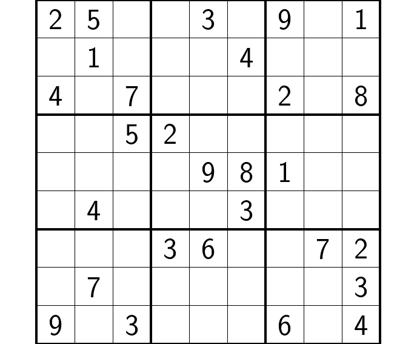

### Tikz package code

Let’s now finally add examples using the famous *tikz* package or packages build on top of the *tkiz* package.

At first a flowchart (`{.mtex packages="tikz" latex="pdflatex"}`):

```
\begin{tikzpicture}[ultra thick,scale=1.5, every node/.style={scale=1.5}]
\node (A) at (0,0) [circle,shade,draw] {$\sin(x)$};
\node (B) at (3,0) {$\cos(x)$};
\node (C) at (6,0) [fill=red!50] {$-\sin(x)$};
\draw[->, blue!50, ultra thick] (A) to[bend right=20]
node[above] {$\frac{\partial}{\partial x}$} (B);
\draw[->, blue!50, ultra thick] (B) to (C);
\draw[<->, ultra thick] (A) to[out=45, in=135] (C);
\end{tikzpicture}
```

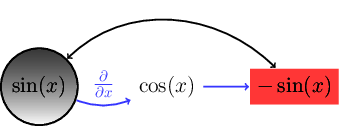

For more possibilities to use tikz graphics you should have a look at the *tikz* and at the *pgf* manual.

And here a plot using the *pgfplot* package `{.mtex packages="pgfplots" latex="pdflatex"}`.

```
\begin{tikzpicture}
    \begin{axis}[domain=0:1,legend pos=outer north east]
    \addplot {sin(deg(x))};
    \addplot {cos(deg(x))};
    \addplot {x^2};
    \legend{$\sin(x)$,$\cos(x)$,$x^2$}
    \end{axis}
\end{tikzpicture}
```

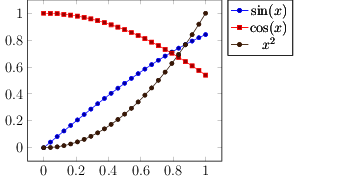

Here an example for the *smartdiagram* LaTeX package: `{.mtex packages="smartdiagram" latex="pdflatex"}`

```
\scalebox{1.5}{ % enlarge the size
\smartdiagram[circular diagram:clockwise]{Edit,
  pdf\LaTeX, Bib\TeX/ biber, make\-index, pdf\LaTeX}
}
```

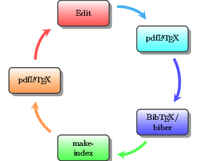

For more examples for the smartdiagram package see the documentation: #’ https://texdoc.org/serve/smartdiagram/0

Sometimes you need more code to be added to the document header not only a few usepackage commands. To include more lines of LaTeX code before the acutal document section you can use the *header* code chunk option like shown here (`{.mtex packages="tikz" header="tikz-tree.tex" latex="pdflatex" ext="svg" resize="150%"}`). WE further set the output format to *svg* to improve the display quality:

```
\scalebox{1.1}{
\begin{tikzpicture}
  [
    grow                    = right,
    sibling distance        = 5em,
    level distance          = 6em,
    edge from parent/.style = {draw, -latex},
    every node/.style       = {font=\small},
    sloped
  ]
  \node [root] {Formula}
    child { node [env] {equation}
      edge from parent node [below] {single-line?} }
    child { node [dummy] {}
      child { node [dummy] {}
        child { node [env] {align\\flalign}
          edge from parent node [below] {at relation sign?} }
        child { node [env] {alignat}
          edge from parent node [above] {at several}
                           node [below] {places?} }
        child { node [env] {gather}
                edge from parent node [above] {centered?} }
        edge from parent node [below] {aligned?} }
      child { node [env] {multline}
              edge from parent node [above, align=center]
                {first left,\\centered,}
              node [below] {last right}}
              edge from parent node [above] {multi-line?} };
\end{tikzpicture}
}
```

[figure not shown]

And now as well a *tikz* based calendar (`{.mtex packages="[calendar]tikz" latex="pdflatex"}`):

```
\tikz
\calendar
    [dates=2022-01-01 to 2022-02-last,week list,
     month label above centered]
    if (Sunday) [red]
    if (Saturday) [red]
    if (equals=2022-02-14) [blue];
```

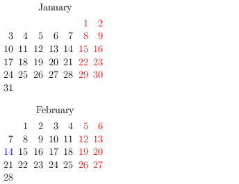

The *tikz* library supports as well programming with LaTeX code `({.mtex packages="tikz" latex="pdflatex"}`):

```
\scalebox{1.5}{
\begin{tikzpicture}
\foreach \x in {0,1,2,3}
   \foreach \y in {0,1,2,3}
     {
       \draw (\x,\y) circle (0.2cm);
       \fill (\x,\y) circle (0.1cm);
     }
\end{tikzpicture}}
```

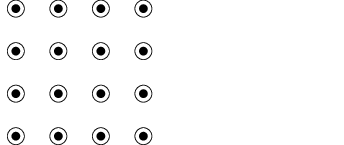

And here a mindmap example (`{.mtex packages="tikz" latex="latex" ext="svg"}`):

```
\tikz
[root concept/.append style={concept color=red!30},
   level 1 concept/.append style={concept color=red!20},
   level 2 concept/.append style={concept color=red!10},
   mindmap]
\node [concept] {Root concept}
   child[grow=30] {node[concept] {child 2}}
   child[grow=0 ] {node[concept] {child 3}
       child[grow=0] { node[concept] {grandchild}}}
   child[grow=60] {node[concept] {child 1}};
```

[figure not shown]

There is as well the possibilty to create handwrite-like charts. Here an example (`{.mtex latex="xelatex" ext="svg" header="xkcd.tex"}`):

```
  \begin{tikzpicture}[xscale=4, yscale=0.05]
    \node at (-0.65,100) {100};
    \node at (-0.65, 50) { 50};
    \node at (-0.65,  0) {  0};
    \node at (0.5,115) {\large Claims of supernatural powers};
    \begin{scope}[very thick, every path/.style={xkcd}]
      \fill[fill=pltblue] (0.875,1) -- ++(0,99) -- ++(0.25,0) -- +(0,-99) -- cycle;
      \draw (0.875,1) -- ++(0,99) -- ++(0.25,0) -- +(0,-99);
      \draw[ultra thick] (0,3) -- (0,0) node[below, text width=3.4cm, align=center] {confirmed by\\ experiment};
      \draw[ultra thick] (1,3) -- (1,0) node[below, text width=3cm, align=center] {refuted by\\ experiment};
      \draw (-0.54,0) -- (1.5,0);
      \draw (-0.5,0) -- (-0.5,110);
      \draw (-0.54,100) -- (-0.46,100);
      \draw (-0.54,50)  -- (-0.46,50);
    \end{scope}
  \end{tikzpicture}
```

[figure not shown]

## See also:

- Pantcl Readme
- EQN filter

## LaTeX links

- LaTeX cookbook: https://latex-cookbook.net/
- Package documentation (see https://texdoc.org/:
  - https://texdoc.org/serve/tikz/0
  - https://texdoc.org/serve/pgf/0
  - [https://texdoc.org/serve/pgfplots/0](https://texdoc.org/serve/tikz/0)
  - [https://texdoc.org/serve/smartdiagram/0](https://texdoc.org/serve/tikz/0)